## In-class worksheet 5

**Jan 30, 2018**

## 1. Tidy data

Is the `iris` dataset tidy? Explain why or why not.

```r
head(iris)
```

```
##   Sepal.Length Sepal.Width Petal.Length Petal.Width Species
## 1          5.1         3.5          1.4         0.2  setosa
## 2          4.9         3.0          1.4         0.2  setosa
## 3          4.7         3.2          1.3         0.2  setosa
## 4          4.6         3.1          1.5         0.2  setosa
## 5          5.0         3.6          1.4         0.2  setosa
## 6          5.4         3.9          1.7         0.4  setosa
```

*Yes, it is tidy. It meets the three rules*

Is the `HairEyeColor` dataset tidy? Explain why or why not.

```r
HairEyeColor
```

```
## , , Sex = Male
##
##        Eye
## Hair    Brown Blue Hazel Green
##   Black    32   11    10     3
##   Brown    53   50    25    15
##   Red      10   10     7     7
##   Blond     3   30     5     8
##
## , , Sex = Female
##
##        Eye
## Hair    Brown Blue Hazel Green
##   Black    36    9     5     2
##   Brown    66   34    29    14
##   Red      16    7     7     7
##   Blond     4   64     5     8
```

*No, it is not. The variablea are Eye color, Hair color, Sex, and person.*

## 2. Selecting rows and columns

All subsequent code will be based on the dplyr library, which is part of the tidyverse. So we first have to load this library:

```r
library(tidyverse)
```

Now, using the dplyr function `filter()`, pick all the rows in the `iris` dataset that pertain to species setosa, and store them in a new table called `iris.setosa`.

```r
iris.setosa <- filter(iris, Species=='setosa')
head(iris.setosa)
```

```
##   Sepal.Length Sepal.Width Petal.Length Petal.Width Species
## 1          5.1         3.5          1.4         0.2  setosa
## 2          4.9         3.0          1.4         0.2  setosa
## 3          4.7         3.2          1.3         0.2  setosa
## 4          4.6         3.1          1.5         0.2  setosa
## 5          5.0         3.6          1.4         0.2  setosa
## 6          5.4         3.9          1.7         0.4  setosa
```

Pick all the rows in the `iris` dataset where species virginica has a sepal length > 7.

```r
filter(iris, Sepal.Length>7 & Species=='virginica')
```

```
##    Sepal.Length Sepal.Width Petal.Length Petal.Width   Species
## 1           7.1         3.0          5.9         2.1 virginica
## 2           7.6         3.0          6.6         2.1 virginica
## 3           7.3         2.9          6.3         1.8 virginica
## 4           7.2         3.6          6.1         2.5 virginica
## 5           7.7         3.8          6.7         2.2 virginica
## 6           7.7         2.6          6.9         2.3 virginica
## 7           7.7         2.8          6.7         2.0 virginica
## 8           7.2         3.2          6.0         1.8 virginica
## 9           7.2         3.0          5.8         1.6 virginica
## 10          7.4         2.8          6.1         1.9 virginica
## 11          7.9         3.8          6.4         2.0 virginica
## 12          7.7         3.0          6.1         2.3 virginica
```

Are there any cases in the `iris` dataset for which the ratio of sepal length to sepal width exceeds the ratio of petal length to petal width? Use `filter()` to find out.

```r
filter(iris, Sepal.Length/Sepal.Width > Petal.Length/Petal.Width)
```

```
##   Sepal.Length Sepal.Width Petal.Length Petal.Width   Species
## 1          6.9         3.1          5.1         2.3 virginica
```

Create a pared-down table which contains only data for species setosa and which only has the columns `Sepal.Length` and `Sepal.Width`. Store the result in a table called `iris.pared`.

```r
iris.pared0 <- select(iris.setosa,Sepal.Length,Sepal.Width)
head(iris.pared0)
```

```
##   Sepal.Length Sepal.Width
## 1          5.1         3.5
## 2          4.9         3.0
## 3          4.7         3.2
## 4          4.6         3.1
## 5          5.0         3.6
## 6          5.4         3.9
```

```r
# first extract all data for species setosa
iris.setosa <- filter(iris, Species=='setosa')
# now select sepal length and width
iris.pared <- select(iris.setosa, Sepal.Length, Sepal.Width)
head(iris.pared)
```

```
##   Sepal.Length Sepal.Width
## 1          5.1         3.5
## 2          4.9         3.0
## 3          4.7         3.2
## 4          4.6         3.1
## 5          5.0         3.6
## 6          5.4         3.9
```

## 3. Creating new data, arranging

Using the function `mutate()`, create a new data column that holds the ratio of sepal length to sepal width. Store the resulting table in a variable called `iris.ratio`.

```r
iris.ratio <- mutate(iris, sepal.length.to.width = Sepal.Length/Sepal.Width)
head(iris.ratio)
```

```
##   Sepal.Length Sepal.Width Petal.Length Petal.Width Species
## 1          5.1         3.5          1.4         0.2  setosa
## 2          4.9         3.0          1.4         0.2  setosa
## 3          4.7         3.2          1.3         0.2  setosa
## 4          4.6         3.1          1.5         0.2  setosa
## 5          5.0         3.6          1.4         0.2  setosa
## 6          5.4         3.9          1.7         0.4  setosa
##   sepal.length.to.width
## 1              1.457143
## 2              1.633333
## 3              1.468750
## 4              1.483871
## 5              1.388889
## 6              1.384615
```

Order the `iris.ratio` table by species name and by increasing values of sepal length-to-width ratio.

```r
iris.ratio.ordered <- arrange(iris.ratio, Species, sepal.length.to.width)
head(iris.ratio.ordered)
```

```
##   Sepal.Length Sepal.Width Petal.Length Petal.Width Species
## 1          5.2         4.1          1.5         0.1  setosa
## 2          4.6         3.6          1.0         0.2  setosa
## 3          5.7         4.4          1.5         0.4  setosa
## 4          5.5         4.2          1.4         0.2  setosa
## 5          5.1         3.8          1.5         0.3  setosa
## 6          5.1         3.8          1.9         0.4  setosa
##   sepal.length.to.width
## 1              1.268293
## 2              1.277778
## 3              1.295455
## 4              1.309524
## 5              1.342105
## 6              1.342105
```

## 4. Grouping and summarizing

Calculate the mean and standard deviation of the sepal lengths for each species. Do this by first creating a table grouped by species, which you call `iris.grouped`. Then run `summarize()` on that table.

```r
iris.grouped <- group_by(iris, Species)
head(iris.grouped)
```

```
## # A tibble: 6 x 5
## # Groups:   Species [1]
##   Sepal.Length Sepal.Width Petal.Length Petal.Width Species
##          <dbl>       <dbl>        <dbl>       <dbl> <fct>
## 1         5.10        3.50         1.40       0.200 setosa
## 2         4.90        3.00         1.40       0.200 setosa
## 3         4.70        3.20         1.30       0.200 setosa
## 4         4.60        3.10         1.50       0.200 setosa
## 5         5.00        3.60         1.40       0.200 setosa
## 6         5.40        3.90         1.70       0.400 setosa
```

```r
summarize(iris.grouped,
            mean.sepal.length = mean(Sepal.Length),
            sd.sepal.length = sd(Sepal.Length))
```

```
## # A tibble: 3 x 3
##   Species    mean.sepal.length sd.sepal.length
##   <fct>                  <dbl>           <dbl>
## 1 setosa                  5.01           0.352
## 2 versicolor              5.94           0.516
## 3 virginica               6.59           0.636
```

Use the function `n()` to count the number of observations for each species.

```r
summarize(iris.grouped, count = n())
```

```
## # A tibble: 3 x 2
##   Species    count
##   <fct>      <int>
## 1 setosa        50
## 2 versicolor    50
## 3 virginica     50
```

For each species, calculate the percentage of cases with sepal length > 5.5.

```r
summarize(iris.grouped, percent = sum(Sepal.Length>5.5)/n())
```

```
## # A tibble: 3 x 2
##   Species    percent
##   <fct>        <dbl>
## 1 setosa      0.0600
## 2 versicolor  0.780
## 3 virginica   0.980
```

## 5. If this was easy

Take the `iris.ratio` data set you have created and plot the distribution of sepal length-to-width ratios for the three species.

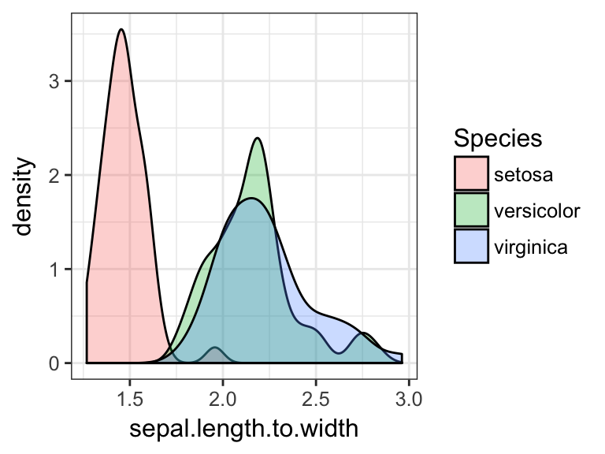

```r
# ggplot2 is part of tidyverse, so we don't need to load it separately
theme_set(theme_bw(base_size=12)) # change the ggplot2 theme
ggplot(iris.ratio, aes(x=sepal.length.to.width, fill=Species)) + geom_density(alpha=.3)
```

Now plot sepal length-to-width ratios vs. sepal lengths. Does it look like there is a relationship between the length-to-width ratios and the lengths? Does it matter whether you consider each species individually or all together? How could you find out?

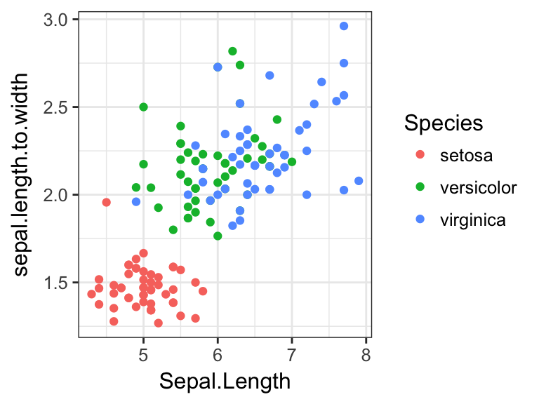

```r
ggplot(iris.ratio, aes(y=sepal.length.to.width, x=Sepal.Length, color=Species)) + geom_point()
```

```r
# Setosa
setosa.ratio <- filter(iris.ratio, Species=='setosa')
cor.test(setosa.ratio$Sepal.Length, setosa.ratio$sepal.length.to.width)
```

```
##
##  Pearson's product-moment correlation
##
## data:  setosa.ratio$Sepal.Length and setosa.ratio$sepal.length.to.width
## t = -1.1218, df = 48, p-value = 0.2675
## alternative hypothesis: true correlation is not equal to 0
## 95 percent confidence interval:
##  -0.4195161  0.1240336
## sample estimates:
##        cor
## -0.1598322
```

```r
# Versicolor
versicolor.ratio <- filter(iris.ratio, Species=='versicolor')
cor.test(versicolor.ratio$Sepal.Length, versicolor.ratio$sepal.length.to.width)
```

```
##
##  Pearson's product-moment correlation
##
## data:  versicolor.ratio$Sepal.Length and versicolor.ratio$sepal.length.to.width
## t = 1.7522, df = 48, p-value = 0.08613
## alternative hypothesis: true correlation is not equal to 0
## 95 percent confidence interval:
##  -0.03559303  0.49008499
## sample estimates:
##       cor
## 0.2451838
```

```r
# Virginica
virginica.ratio <- filter(iris.ratio, Species=='virginica')
cor.test(virginica.ratio$Sepal.Length, virginica.ratio$sepal.length.to.width)
```

```
##
##  Pearson's product-moment correlation
##
## data:  virginica.ratio$Sepal.Length and virginica.ratio$sepal.length.to.width
## t = 3.5015, df = 48, p-value = 0.001011
## alternative hypothesis: true correlation is not equal to 0
## 95 percent confidence interval:
##  0.1975161 0.6480484
## sample estimates:
##       cor
## 0.4510651
```

[output not shown]